# Week_12_Assignment

Sekhar Mekala

Thursday, April 23, 2015

## Creating a JSON file to be inserted into a mongodb collection

The following R code gets a JSON document from nytimes.com website, via API. This JSON document contains a books categories available at nytimes.com website

### R Code to fetch books categories

```r
library(RCurl)
library(jsonlite)
url <- "http://api.nytimes.com/svc/books/v3/lists/names.json?api-key=ae3ebf8d2c14b1623769762cea332b83:0:71863562"

web_data <- getURL(url)

categories_df <- fromJSON(web_data)$results

print(categories_df)
```

```
##                               list_name
## 1     Combined Print and E-Book Fiction
## 2  Combined Print and E-Book Nonfiction
## 3                     Hardcover Fiction
## 4                  Hardcover Nonfiction
## 5               Trade Fiction Paperback
## 6                 Mass Market Paperback
## 7                  Paperback Nonfiction
## 8                        E-Book Fiction
## 9                     E-Book Nonfiction
## 10                     Hardcover Advice
## 11                     Paperback Advice
## 12      Advice How-To and Miscellaneous
## 13                        Picture Books
## 14                        Chapter Books
```

[output cut: 177 more lines]

Let us convert back the data frame (categories_df) to a JSON document. In the following R code the JSON document is placed at “C:/Users/Sekhar/Documents/CUNY/MongoDB/books.json”

```r
categories_json <- toJSON(categories_df)
fileconn <- file("C:/Users/Sekhar/Documents/CUNY/MongoDB/books.json")
writeLines(categories_json, fileconn)
close(fileconn)
```

## Checking the contents of the collection

At the mongo.exe prompt, enter the following commands, to check the available collections:

**use nytimes**

**db.getCollectionNames()**

The first command connects to nytimes database, and the second command displays the available collection names in the database. See the display below:

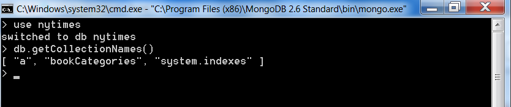

The command **db.bookCategories.find().pretty().limit(5)** will display the first 5 documents of the collection **bookCategories**. See the below display (NOTE that the number of documents display is restricted to just 5, using the limit(5) option so that we are able to display the command along with the results in a single dos window. If you use **db.bookCategories.find().pretty()** command, then all the results of the collection are displayed:

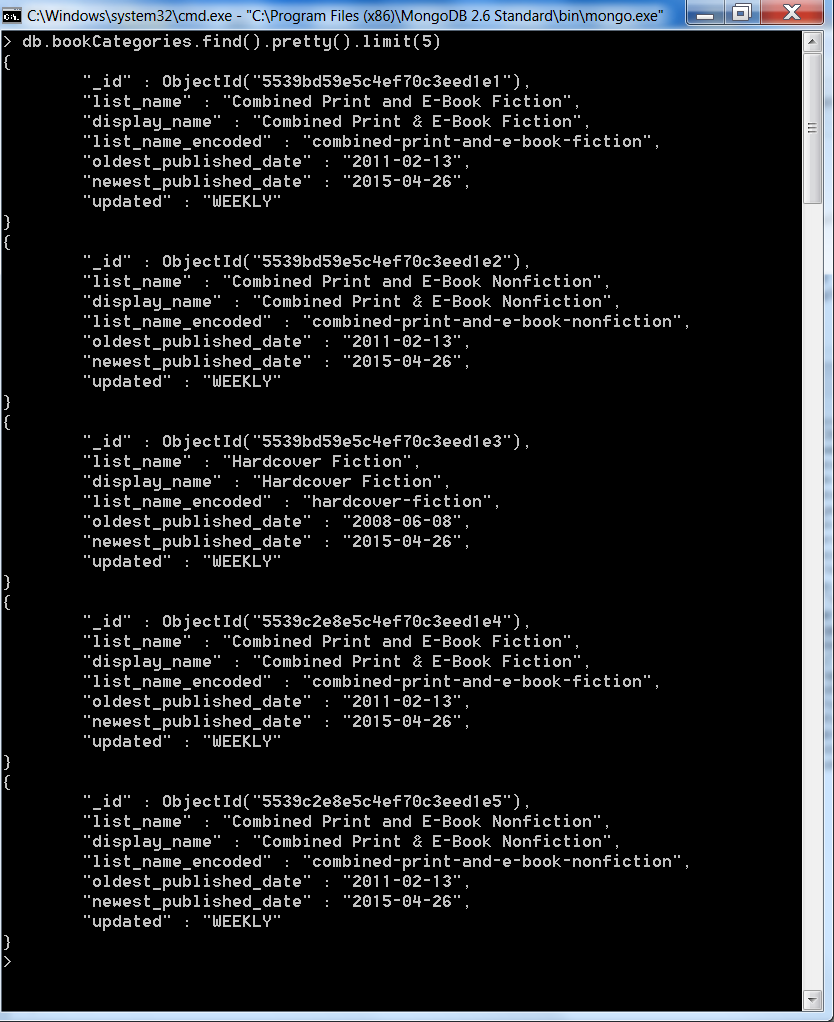

## Connecting to the local mongodb and reading a collection’s documents to a R dataframe

**NOTE** There is an excellent document on rmongodb usage at the website: http://cran.r-project.org/web/packages/rmongodb/vignettes/rmongodb_introduction.html

Most of the commands I used below were taken from that website.

```r
#Install rmongodb package, if the package is not installed
#install.packages("rmongodb")


library(rmongodb)
library(data.table)
#Create a connection to the mongodb() process
mongo <- mongo.create()

#Get the collections we have in the "nytimes" database
mongo.get.database.collections(mongo, "nytimes")
```

```
## [1] "nytimes.a"              "nytimes.bookCategories"
```

```r
#We will use the "bookCategories" collection name in "nytimes" database, to read its documents
# Note how we referenced the collection name qualified with database name

coll <- "nytimes.bookCategories"
x <- mongo.find.all(mongo, coll)

#Converting the collection's documents to a data frame in R
books_df <- data.frame(rbindlist(lapply(x,as.list)))
print(books_df)
```

```
##                         X_id                            list_name
## 1   5539bd59e5c4ef70c3eed1e1    Combined Print and E-Book Fiction
## 2   5539bd59e5c4ef70c3eed1e2 Combined Print and E-Book Nonfiction
## 3   5539bd59e5c4ef70c3eed1e3                    Hardcover Fiction
## 4   5539c2e8e5c4ef70c3eed1e4    Combined Print and E-Book Fiction
## 5   5539c2e8e5c4ef70c3eed1e5 Combined Print and E-Book Nonfiction
## 6   5539c2e8e5c4ef70c3eed1e6                    Hardcover Fiction
## 7   5539c2e8e5c4ef70c3eed1e7                 Hardcover Nonfiction
## 8   5539c2e8e5c4ef70c3eed1e8              Trade Fiction Paperback
## 9   5539c2e8e5c4ef70c3eed1e9                Mass Market Paperback
## 10  5539c2e8e5c4ef70c3eed1ea                 Paperback Nonfiction
## 11  5539c2e8e5c4ef70c3eed1eb                       E-Book Fiction
## 12  5539c2e8e5c4ef70c3eed1ec                    E-Book Nonfiction
## 13  5539c2e8e5c4ef70c3eed1ed                     Hardcover Advice
## 14  5539c2e8e5c4ef70c3eed1ee                     Paperback Advice
```

[output cut: 941 more lines]

The above code connects to mongodb, reads the documents of a collection present in nytimes database, and finally converts the documents to a R data frame.

You may optionally execute the following R code to remove the _ID column from the data frame

```r
books_df[1] <- NULL

head(books_df)
```

```
##                              list_name                       display_name
## 1    Combined Print and E-Book Fiction    Combined Print & E-Book Fiction
## 2 Combined Print and E-Book Nonfiction Combined Print & E-Book Nonfiction
## 3                    Hardcover Fiction                  Hardcover Fiction
## 4    Combined Print and E-Book Fiction    Combined Print & E-Book Fiction
## 5 Combined Print and E-Book Nonfiction Combined Print & E-Book Nonfiction
## 6                    Hardcover Fiction                  Hardcover Fiction
##                      list_name_encoded oldest_published_date
## 1    combined-print-and-e-book-fiction            2011-02-13
## 2 combined-print-and-e-book-nonfiction            2011-02-13
## 3                    hardcover-fiction            2008-06-08
## 4    combined-print-and-e-book-fiction            2011-02-13
## 5 combined-print-and-e-book-nonfiction            2011-02-13
## 6                    hardcover-fiction            2008-06-08
##   newest_published_date updated
## 1            2015-04-26  WEEKLY
## 2            2015-04-26  WEEKLY
## 3            2015-04-26  WEEKLY
## 4            2015-04-26  WEEKLY
## 5            2015-04-26  WEEKLY
## 6            2015-04-26  WEEKLY
```

-~-End of Assignment-~-